# Lab 07

Brooke Grazda

2023-11-15

#### Step #1: Set global options and load packages

#### Step #2: Import water use data, clean data

**Table 1: “Sets” of data, for which each of the sets have ALL column tags in common. Data from USGS (1950-2015). The data for this lab are available from the [United States Geological Survey](https://water.usgs.gov/watuse/data/) for years 1950-2015.**

| year | public supply | irrigation | rural | industrial | thermo | state |
| --- | --- | --- | --- | --- | --- | --- |
| 1950-1955 | ps_wgw_fr + ps_wsw_fr | ir_wgw_fr + ir_wsw_fr | NA | inpt_wgw_fr + inpt_wsw_fr | NA | area |
| 1960-1980 | ps_wgw_fr + ps_wgw_fr | ir_wgw_fr + ir_wsw_fr | do_wgw_fr + do_wsw_fr + ls_wgw_fr + ls_wsw_fr | oi_wgw_fr + oi_wsw_fr | pt_wgw_fr + pt_wsw_fr | area |
| 1985-1990 | ps_wgwfr + ps_wswfr | ir_wgwfr + ir_wswfr | do_ssgwf + do_ssswf + ls_gwtot + ls_swtot | in_wgwfr + in_wswfr + mi_wgwfr + mi_wswfr | pt_wgwfr + pt_wswfr | scode |
| 1995 | ps_wgw_fr + ps_wsw_fr | ir_wgw_fr + ir_wsw_fr | do_wgw_fr + do_wsw_fr + ls_wgw_fr + ls_wsw_fr | in_wgw_fr + in_wsw_fr + mi_wgw_fr + mi_wsw_fr | pt_wgw_fr + pt_wsw_fr | state_code |
| 2000 | ps_wgw_fr + ps_wsw_fr | it_wgw_fr + it_wsw_fr | do_wgw_fr + do_wsw_fr + ls_wgw_fr + ls_wsw_fr | in_wgw_fr + in_wsw_fr + mi_wgw_fr + mi_wsw_fr | pt_wgw_fr + pt_wsw_fr | statefips |
| 2005 | ps_wgw_fr + ps_wsw_fr | ir_wgw_fr + ir_wsw_fr | do_wgw_fr + do_wsw_fr + ls_wgw_fr + ls_wsw_fr | in_wgw_fr + in_wsw_fr + mi_wgw_fr + mi_wsw_fr | pt_wgw_fr + pt_wsw_fr | state_fips |
| 2010 - 2015 | ps_wgw_fr + ps_wsw_fr | ir_wgw_fr + ir_wsw_fr | do_wgw_fr + do_wsw_fr + li_wgw_fr + li_wsw_fr | in_wgw_fr + in_wsw_fr + mi_wgw_fr + mi_wsw_fr | pt_wgw_fr + pt_wsw_fr | statefips |

#### Step 3: Organize data by sector

```r
#assign new variables
wu_1950 <- d_1950 |>                                        #calls the year 1950
           select("area", contains(c("wsw_fr", "wgw_fr"))) |>                        #copies necessary columns, excludes saline withdrawal
           mutate(public_supply = ps_wsw_fr + ps_wgw_fr,                             #sum public supply columns
                    irrigation = ir_wgw_fr + ir_wsw_fr,                           #sum irrigation columnes
                     rural = NA,                                                  #sum rural columns except its NA
                    industrial = inpt_wgw_fr + inpt_wsw_fr,                       #sum industrial columns
                     thermoelectric = NA,                                        #thermoelectric columns except NA
                    state = area, na.rm = TRUE)  |>                                              #reassign area to state
        select("public_supply", "irrigation", "rural", "industrial", "thermoelectric", "state") |>           #select only the columns i want
        mutate(year = 1950) |>
        pivot_longer(cols = 1:5, names_to = "sector", values_to = "withdrawals")

wu_1955 <- d_1955 |>                                                                #year!
           select("area", contains(c("wsw_fr", "wgw_fr"))) |>                        #copies necessary columns, excludes saline withdrawal
           mutate(public_supply = ps_wsw_fr + ps_wgw_fr,                             #sum public supply columns
                    irrigation = ir_wgw_fr + ir_wsw_fr,                           #sum irrigation columnes
                     rural = NA,                                                  #sum rural columns except its NA
                    industrial = inpt_wgw_fr + inpt_wsw_fr,                       #sum industrial columns
                     thermoelectric = NA,                                        #thermoelectric columns except NA
                    state = area, na.rm = TRUE)  |>                                              #reassign area to state
        select("public_supply", "irrigation", "rural", "industrial", "thermoelectric", "state") |>           #select only the columns i want
        mutate(year = 1955) |>
        pivot_longer(cols = 1:5, names_to = "sector", values_to = "withdrawals")

wu_1960 <- d_1960 |>                                                                #year!
           mutate(public_supply = ps_wsw_fr + ps_wgw_fr,                             #sum public supply columns
                   #totsl irrigation withdrawals since lack of data that was making my ggplot look funny before
                   irrigation = ir_w_fr_to,                           #sum irrigation columnes
                     rural = do_wgw_fr + do_wsw_fr + ls_wgw_fr + ls_wsw_fr,                                                  #sum rural columns except its NA
                    industrial = oi_wgw_fr + oi_wsw_fr,                       #sum industrial columns
                     thermoelectric = pt_wgw_fr + pt_wsw_fr,                                        #thermoelectric columns except NA
                    state = area, na.rm = TRUE)  |>                                              #reassign area to state
        select("public_supply", "irrigation", "rural", "industrial", "thermoelectric", "state") |>           #select only the columns i want
       mutate(year = 1960) |>
      pivot_longer(cols = 1:5, names_to = "sector", values_to = "withdrawals")

wu_1965 <- d_1965 |>                                                                #year!
           select("area", contains(c("wsw_fr", "wgw_fr"))) |>                        #copies necessary columns, excludes saline withdrawal
           mutate(public_supply = ps_wsw_fr + ps_wgw_fr,                             #sum public supply columns
                    irrigation = ir_wgw_fr + ir_wsw_fr,                           #sum irrigation columnes
                     rural = do_wgw_fr + do_wsw_fr + ls_wgw_fr + ls_wsw_fr,                                                  #sum rural columns except its NA
                    industrial = oi_wgw_fr + oi_wsw_fr,                       #sum industrial columns
                     thermoelectric = pt_wgw_fr + pt_wsw_fr,                                        #thermoelectric columns
                    state = area, na.rm = TRUE)  |>                                              #reassign area to state
          select("public_supply", "irrigation", "rural", "industrial", "thermoelectric", "state") |>            #select only the columns i want
          mutate(year = 1965) |>
          pivot_longer(cols = 1:5, names_to = "sector", values_to = "withdrawals")

wu_1970 <- d_1970 |>                                                                #year!
           select("area", contains(c("wsw_fr", "wgw_fr"))) |>                        #copies necessary columns, excludes saline withdrawal
           mutate(public_supply = ps_wsw_fr + ps_wgw_fr,                             #sum public supply columns
                    irrigation = ir_wgw_fr + ir_wsw_fr,                           #sum irrigation columnes
                     rural = do_wgw_fr + do_wsw_fr + ls_wgw_fr + ls_wsw_fr,                                                  #sum rural columns
                    industrial = oi_wgw_fr + oi_wsw_fr,                       #sum industrial columns
                     thermoelectric = pt_wgw_fr + pt_wsw_fr,                                        #thermoelectric columns
                    state = area, na.rm = TRUE)  |>                                              #reassign area to state
          select("public_supply", "irrigation", "rural", "industrial", "thermoelectric", "state") |>           #select only the columns i want
         mutate(year = 1970) |>
         pivot_longer(cols = 1:5, names_to = "sector", values_to = "withdrawals")

wu_1975 <- d_1975 |>                                                                #year!
           select("area", contains(c("wsw_fr", "wgw_fr"))) |>                        #copies necessary columns, excludes saline withdrawal
           mutate(public_supply = ps_wsw_fr + ps_wgw_fr,                             #sum public supply columns
                    irrigation = ir_wgw_fr + ir_wsw_fr,                           #sum irrigation columnes
                     rural = do_wgw_fr + do_wsw_fr + ls_wgw_fr + ls_wsw_fr,                                                  #sum rural columns
                    industrial = oi_wgw_fr + oi_wsw_fr,                       #sum industrial columns
                     thermoelectric = pt_wgw_fr + pt_wsw_fr,                                        #thermoelectric columns
                    state = area, na.rm = TRUE)  |>                                              #reassign area to state
          select("public_supply", "irrigation", "rural", "industrial", "thermoelectric", "state") |>           #select only the columns i want
          mutate(year = 1975) |>
          pivot_longer(cols = 1:5, names_to = "sector", values_to = "withdrawals")
```

```r
wu_1980 <- d_1980 |>                                                                #year!
           select("area", contains(c("wsw_fr", "wgw_fr"))) |>                        #copies necessary columns, excludes saline withdrawal
           mutate(public_supply = ps_wsw_fr + ps_wgw_fr,                             #sum public supply columns
                    irrigation = ir_wgw_fr + ir_wsw_fr,                           #sum irrigation columns
                     rural = do_wgw_fr + do_wsw_fr + ls_wgw_fr + ls_wsw_fr,                                                  #sum rural columns
                    industrial = oi_wgw_fr + oi_wsw_fr,                       #sum industrial columns
                     thermoelectric = pt_wgw_fr + pt_wsw_fr,                                        #thermoelectric columns
                    state = area, na.rm = TRUE)  |>                                              #reassign area to state
          select("public_supply", "irrigation", "rural", "industrial", "thermoelectric", "state") |>           #select only the columns i want
          mutate(year = 1980) |>
        pivot_longer(cols = 1:5, names_to = "sector", values_to = "withdrawals")

wu_1985 <- d_1985 |>
           select("scode", contains(c("sw", "gw"))) |>
           mutate(public_supply = ps_wswfr + ps_wgwfr,                             #sum public supply columns
                    irrigation = ir_wgwfr + ir_wswfr,                           #sum irrigation columnes
                     rural = do_ssgwf + do_ssswf + ls_gwtot + ls_swtot,                      #sum rural columns
                    industrial = in_wgwfr + in_wswfr + mi_wgwfr + mi_wswfr,                       #sum industrial columns
                     thermoelectric = pt_wgwfr + pt_wswfr,                                        #thermoelectric columns
                    state = scode, na.rm = TRUE)  |>                                              #reassign area to state
          select("public_supply", "irrigation", "rural", "industrial", "thermoelectric", "state") |>           #select only the columns i want)
         group_by(state) |>                                                          #looks at state column and groups values
         summarize_at(c(1:5), sum) |>                                                #sum up the states
         ungroup()      |>                                                              #ungroups to prevent errors
         mutate(year = 1985) |>
        pivot_longer(cols = 2:6, names_to = "sector", values_to = "withdrawals")

wu_1990 <- d_1990 |>
          select("scode", contains(c("sw", "gw"))) |>
           mutate(public_supply = ps_wswfr + ps_wgwfr,                                #sum public supply columns
                    irrigation = ir_wgwfr + ir_wswfr,                                 #sum irrigation columnes
                     rural = do_ssgwf + do_ssswf + ls_gwtot + ls_swtot,                                                  #sum rural columns
                    industrial = in_wgwfr + in_wswfr + mi_wgwfr + mi_wswfr,                       #sum industrial columns
                     thermoelectric = pt_wgwfr + pt_wswfr,                                        #thermoelectric columns
                    state = scode, na.rm = TRUE)  |>                                                #reassign area to state
          select("public_supply", "irrigation", "rural", "industrial", "thermoelectric", "state") |>        #only wanted values
         group_by(state) |>                                                          #looks at state column and groups values
         summarize_at(c(1:5), sum) |>                                                #sum up the states
         ungroup()  |>                                                                  #ungroups to prevent errors
       mutate(year = 1990) |>
       pivot_longer(cols = 2:6, names_to = "sector", values_to = "withdrawals")

wu_1995 <- d_1995 |>
           select("state_code", contains(c("wgw_fr", "wsw_fr")))  |>
          mutate(public_supply = ps_wsw_fr + ps_wgw_fr,                                #sum public supply columns
                    irrigation = ir_wgw_fr + ir_wsw_fr,                                 #sum irrigation columnes
                     rural = do_wgw_fr + do_wsw_fr + ls_wgw_fr + ls_wsw_fr,                                                  #sum rural columns
                    industrial = in_wgw_fr + in_wsw_fr + mi_wgw_fr + mi_wsw_fr,                       #sum industrial columns
                     thermoelectric = pt_wgw_fr + pt_wsw_fr,                                        #thermoelectric columns
                    state = state_code, na.rm = TRUE) |>
         select("public_supply", "irrigation", "rural", "industrial", "thermoelectric", "state") |>        #only wanted values
         group_by(state) |>                                                          #looks at state column and groups values
         summarize_at(c(1:5), sum) |>                                                #sum up the states
         ungroup() |>                                                                #no errors here no sir
         mutate(year = 1995) |>
        pivot_longer(cols = 2:6, names_to = "sector", values_to = "withdrawals")

wu_2000 <- d_2000 |>
           select(statefips, contains(c("wgw_fr", "wsw_fr"))) |>                                              #select these ones to narrow down
           mutate(public_supply = ps_wgw_fr + ps_wsw_fr,                                             #public supply sum column
                  irrigation = it_wgw_fr + it_wsw_fr,                                              #irrigation summing columns
                  rural = do_wgw_fr + do_wsw_fr + ls_wgw_fr + ls_wsw_fr,                                              #rural summing col
                  industrial = in_wgw_fr + in_wsw_fr + mi_wgw_fr + mi_wsw_fr,                                             #industrial sum col
                  thermoelectric = pt_wgw_fr + pt_wsw_fr,                                             #thermoelectric sum col
                  state = statefips, na.rm = TRUE)  |>                                                         #state code is fips
          select("public_supply", "irrigation", "rural", "industrial", "thermoelectric", "state") |>
          group_by(state) |>                                                                       #group states
        summarize_at(c(1:5), sum) |>                                                                       #selected columns
         ungroup() |>                                                                             #ungroup
         mutate(year = 2000) |>                                                                       #add column for 2000
        pivot_longer(cols = 2:6, names_to = "sector", values_to = "withdrawals")                                   #now only 4 columns
```

```r
wu_2005 <- d_2005 |>                                                                       #year of interest
          select(statefips, contains(c("wgw_fr", "wsw_fr"))) |>                                   #help search for wanted variables
          mutate(public_supply = ps_wgw_fr + ps_wsw_fr,                                   #sum up
                 irrigation = ir_wgw_fr + ir_wsw_fr,                                   #irrigationsum
                 rural = do_wgw_fr + do_wsw_fr + ls_wgw_fr + ls_wsw_fr,                                   #rural sum
                 industrial = in_wgw_fr + in_wsw_fr + mi_wgw_fr + mi_wsw_fr,                                   #industrial sum
                 thermoelectric = pt_wgw_fr + pt_wsw_fr,                                                 #thermo sum
                 state = statefips, na.rm = TRUE)  |>                                    #state fips char and then ALL values na.rm = true
        select("public_supply", "irrigation", "rural", "industrial", "thermoelectric", "state") |>                                    #only want these
        group_by(state) |>
        summarize_at(c(1:5), sum) |>
        ungroup() |>
        mutate(year = 2005) |>
        pivot_longer(cols = 2:6, names_to = "sector", values_to = "withdrawals")         #same deal group sum then ungroup and add column to get 4 total

wu_2010 <- d_2010 |>
         select(statefips, contains(c("wgw_fr", "wsw_fr"))) |>
          mutate(public_supply = ps_wgw_fr + ps_wsw_fr,
                 irrigation = ir_wgw_fr + ir_wsw_fr,
                 rural = do_wgw_fr + do_wsw_fr + li_wgw_fr + li_wsw_fr,
                 industrial = in_wgw_fr + in_wsw_fr + mi_wgw_fr + mi_wsw_fr,
                 thermoelectric = pt_wgw_fr + pt_wsw_fr,
                 state = statefips, na.rm = TRUE)  |>
        select("public_supply", "irrigation", "rural", "industrial", "thermoelectric", "state") |>      #after summing up correct columns, select them to get only these
        group_by(state) |>
        summarize_at(c(1:5), sum) |>
        ungroup() |>
        mutate(year = 2010) |>
        pivot_longer(cols = 2:6, names_to = "sector", values_to = "withdrawals")   #same deal group sum then ungroup and add column to get 4 total

wu_2015 <- d_2015 |>
         select(statefips, contains(c("wgw_fr", "wsw_fr"))) |>
          mutate(public_supply = ps_wgw_fr + ps_wsw_fr,
                 irrigation = ir_wgw_fr + ir_wsw_fr,
                 rural = do_wgw_fr + do_wsw_fr + li_wgw_fr + li_wsw_fr,
                 industrial = in_wgw_fr + in_wsw_fr + mi_wgw_fr + mi_wsw_fr,
                 thermoelectric = pt_wgw_fr + pt_wsw_fr,
                 state = statefips, na.rm = TRUE)  |>
        select("public_supply", "irrigation", "rural", "industrial", "thermoelectric", "state") |>     #after summing up correct columns, select them to get only these
        group_by(state) |>
        summarize_at(c(1:5), sum) |>
        ungroup() |>
        mutate(year = 2015) |>                    #same deal group sum then ungroup and add column to get 4 total
       pivot_longer(cols = 2:6, names_to = "sector", values_to = "withdrawals")
```

#### Step 4: Organize and combine data for plotting

```r
wu_all <- rbind(wu_1950, wu_1955, wu_1960, wu_1965, wu_1970, wu_1975, wu_1980, wu_1985, wu_1990, wu_1995, wu_2000, wu_2005, wu_2010, wu_2015, deparse.level = 1) |>    #all data binded
          filter(!state %in% c("11", "72", "78"))                               #filter out non states: DC, Puerto Rico, VI

wu_all_total <- wu_all |>                                  #call the previous data frame to make totals
               group_by(year) |>                            #combine by year
               summarize_at(vars("withdrawals"), sum, na.rm = TRUE) |>                            #we want to sum up all the withdrawals per year
               ungroup()                                                      #error prevention

wu_all_sector <- wu_all |>
                group_by(sector, year) |>                  #we want to add up all sectors by year
                summarize_at(vars("withdrawals"), sum, na.rm = TRUE) |>          #sum up withdrawals after grouping
                ungroup()                                #ungroup

wu_all_check <- wu_all_sector |>                         #3 columns
              group_by(sector) |>                        #we don't need to look at year
              summarize_at(vars("withdrawals"), sum, na.rm = TRUE) |>          #sum up withdrawals
              ungroup() |>                              #no errors
              arrange(withdrawals)                   #arranges sectors in ascending order by total withdrawal; ggplot in next step is ordering the sector based on the total sectors for every year
```

#### Step 5: Setup plot for timeseries of sectoral withdrawals

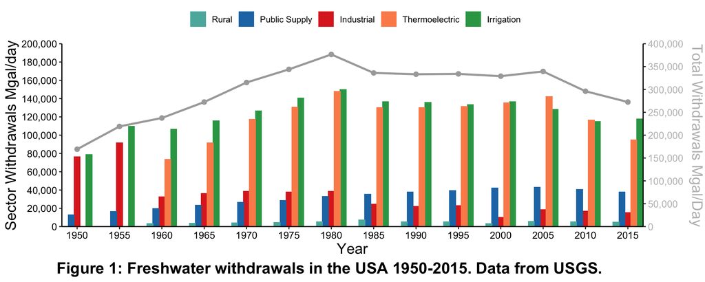

```r
ggplot() +
        geom_col(data = wu_all_sector, aes(x = year, y = withdrawals,               #data frame, x axis is year, y axis is withdrawal
                 fill = reorder(sector, withdrawals, decreasing = FALSE)),          #we want the sector to be reordered based on increasing withdrawals
                 position = position_dodge(3.5),                                   #dodgin bars for visualization
                 width = 4) +                                                     #thickness of bars
        scale_fill_manual(limits = c("rural", "public_supply", "industrial", "thermoelectric", "irrigation"), labels = c("Rural", "Public Supply", "Industrial", "Thermoelectric", "Irrigation"), values = c("#5ab4ac","#1f78b4", "#de2d26","#fc8d59", "#31a354" ))  +        #reassigns colors, gets rid of snake case legend
          geom_line(data = wu_all_total, aes(x = year, y= withdrawals/2),
                    size = 1,
                    colour = "darkgrey") +               #line data in grey
          geom_point(data = wu_all_total, aes(x = year, y = withdrawals/2),
                    size = 2,
                    colour = "darkgrey") +            #plots grey points on the line
                 #removes padding between first and last years (removes 1945 and 2020)
         scale_x_continuous(breaks = scales::pretty_breaks(n = 14), expand = c(0,0)) +     #breaks on the x axis
                 #removes padding between the x axis and the first plotted value
         scale_y_continuous(breaks = scales::pretty_breaks(n = 10), labels = scales::comma, limits = c(0, 200000), sec.axis = sec_axis(trans = ~.*2, breaks = scales::pretty_breaks(n = 10), name = "Total Withdrawals Mgal/Day", labels = scales::comma), expand = c(0,0)) +                       #sets right side secondary axis and names it with limits up to 200,000
          labs(x = "Year", y = "Sector Withdrawals Mgal/day", caption = "Figure 1: Freshwater withdrawals in the USA 1950-2015. Data from USGS.", fill = "") +         #left axes title with labeling x axis and giving caption
      #classic theme removes gridlines and gives a white background
         theme_classic() +
         theme(legend.title = element_text(size = 10, color = "black"),                 #change legend size and color
                     legend.position = "top",                                       #change legend position to top
                      axis.text = element_text(size = 10, color = "black"),         #change axis text on the left and change color to black
                      axis.text.y.right = element_text(color = "grey"),           #put right axis text to be grey
                      axis.title.y.right = element_text(vjust = 2, color = "grey"),          #make right axis title grey
                      axis.title = element_text(size = 15),                     #change title size
                      plot.caption = element_text(hjust = -0.15, size = 16, face = "bold"))           #change caption positioning and size and face
```

**Q1: What is the take home message specific to Figure 1 with respect to water use by sector over time?** Total water withdrawals were increasing up until 1980, and then over time it has decreased. The two major sectors over time have been thermoelectric and irrigation for water withdrawals. 1980 had the greatest year

**Q2: What is the most surprising outcome to you of Figure 1?** The most surprising outcome to me is that we have been able to make water use more efficient so that we can visually see water use decreasing since 1980. I was also surprised to see how little the public supply sector uses water in comparison to other sectors.

**Q3: Go to the USGS plot that shows withdrawals by sector (scroll down, the relevant plot is at the bottom); the bars in the USGS plot show different patterns than our plot. How is the plot different and why?** In the USGS plot, thermoelectric withdrawals are greater than irrigation withdrawals because they do not indicate the type of water withdrawals used. For example, this difference could account for water withdrawals + deliveries in the thermoelectric sector.